# Class 14: Solutions

Tobias Gerstenberg

February 13th, 2021

# 14 Power analysis

## 14.1 Load packages and set plotting theme

```r
library("knitr")      # for knitting RMarkdown
library("broom")      # for tidying up model fits
library("pwr")        # for power calculations
library("car")        # for Anova()
library("tictoc")     # for measuring execution time
library("tidyverse")  # for wrangling, plotting, etc.
```

```r
theme_set(theme_classic() + #set the theme
    theme(text = element_text(size = 20))) #set the default text size

opts_chunk$set(comment = "",
               fig.show = "hold")
```

## 14.2 Practice 1 – Having fun with `map()`

Use the `map2_dbl()` function to create a new variable in this data frame that’s the maximum of each row across columns `a` and `b`.

```r
df = tibble(a = c(12, 14, 52, 23, 23),
            b = c(29, 12, 4, 48, 37))

tic() # start timer
df %>%
  mutate(max = map2_dbl(.x = a,
                        .y = b,
                        .f = ~ max(.x, .y)))
```

```
# A tibble: 5 x 3
      a     b   max
  <dbl> <dbl> <dbl>
1    12    29    29
2    14    12    14
3    52     4    52
4    23    48    48
5    23    37    37
```

```r
toc() # end timer
```

```
0.032 sec elapsed
```

Using `map()` is considerably faster than rowwise grouping.

```r
n = 1000000

df = tibble(a = rnorm(n = n),
            b = rnorm(n = n))

# using map()
tic()
df1 = df %>%
  mutate(max = map2_dbl(.x = a,
                        .y = b,
                        .f = ~ max(.x, .y)))
toc()
```

```
1.467 sec elapsed
```

```r
# alternative
tic()
df2 = df %>%
  rowwise() %>%
  mutate(max = max(a, b)) %>%
  ungroup()
toc()
```

```
3.953 sec elapsed
```

## 14.3 Practice 2 – `map()`ping out the `nest()`

In the `mtcars` data set, run separate linear models with `cyl` (number of cylinders) and `am` (whether the car has automatic or manual transmission) as predictors (including their interaction), and `mpg` (miles per galon), and `hp` (horse power) as dependent variables. Create a data frame that contains one column with the names of the dependent variables, one column with the names of the predictors, and one column with the p-value for each predictor.

Here is the general strategy for how to go about this:

- Make a data frame that only contains the dependent variables.
- Pass that data frame as a first argument to the `map()` function.
- The second argument in the `map()` function (the formula `f. =`) should be a linear model (`lm()`) for which you should use `.x` (the first argument from the `map()` function) as the dependent variable
- Use the `Anova()` function to get the main effects for each of the predictors as well as the interaction effect.
- Use the `tidy()` function in combination with `map_dfr()` to extract the p-values

```r
# write your code here
mtcars %>%
  select(mpg, hp) %>%
  map(.f = ~ lm(.x ~ cyl * am,
                data = mtcars) %>%
        Anova(type = 3)) %>%
  map_dfr(tidy, .id = "source") %>%
  mutate(p.value = round(p.value, digits = 3)) %>%
  na.omit() %>%
  select(source, term, p.value)
```

```
# A tibble: 8 x 3
  source term        p.value
  <chr>  <chr>         <dbl>
1 mpg    (Intercept)   0
2 mpg    cyl           0
3 mpg    am            0.025
4 mpg    cyl:am        0.076
5 hp     (Intercept)   0.225
6 hp     cyl           0
7 hp     am            0.13
8 hp     cyl:am        0.023
```

## 14.4 Practice 3 – Simulation of an interaction effect

Try to run a simulation to determine how many participants you would need to have an 80% chance of rejecting the null hypothesis that there is no interaction based on the following pilot data set:

```r
set.seed(1)
# population parameters
b0 = 1
b1 = 2
b2 = 3
b1_2 = -2
sd = 2
n = 10

df.linear = tibble(x = runif(n = n),
                   y = rep(c(0, 1), each = n/2),
                   z = b0 + b1 * x + b2 * y + b1_2 * x * y + rnorm(n = n, sd = sd))
```

Let’s visualize the pilot data first:

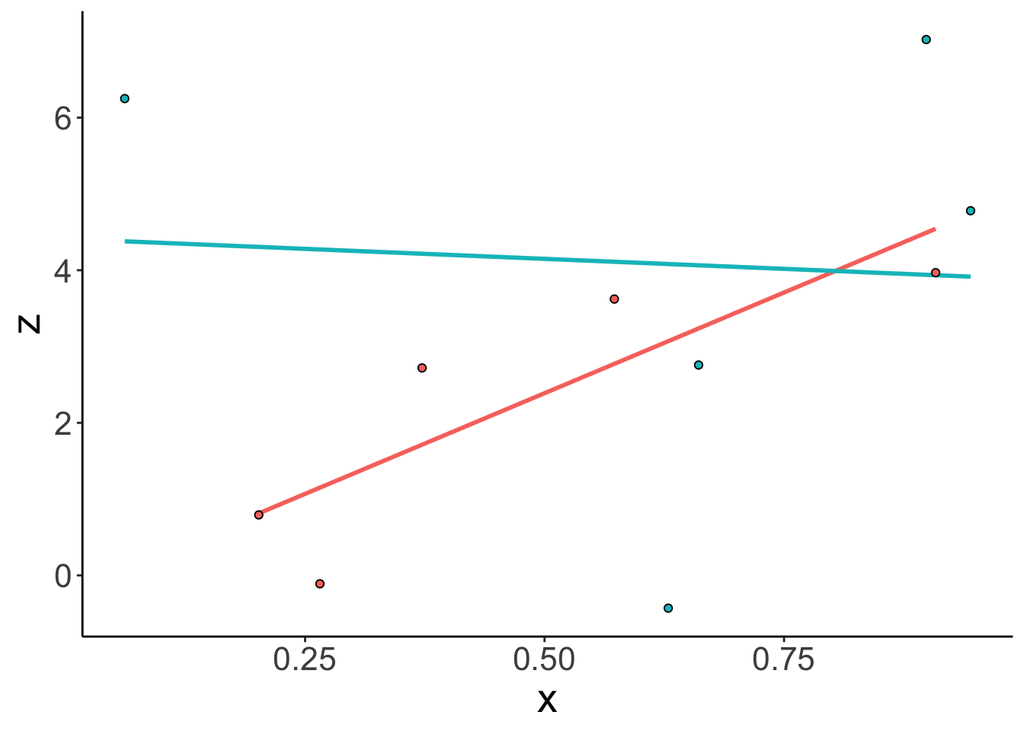

```r
ggplot(data = df.linear,
       mapping = aes(x = x,
                     y = z,
                     group = y,
                     fill = as.factor(y),
                     color = as.factor(y))) +
  geom_smooth(method = "lm",
              se = F,
              show.legend = F) +
  geom_point(shape = 21,
             color = "black",
             show.legend = F)
```

Let’s estimate the parameters based on our sample:

```r
# parameter estimates for the coefficients based on the sample
b = lm(formula = z ~ x * y,
       data = df.linear) %>%
  tidy() %>%
  select(term, estimate, p.value)

# parameter estimate of the residual standard deviation
sigma = lm(formula = z ~ x * y,
           data = df.linear) %>%
  glance() %>%
  pull(sigma)
```

Run a power analysis to see how many participants you would need to have an 80% chance of rejecting the null hypothesis that there is no interaction. Use the parameter estimates (the beta coefficients and the standard deviation of the residuals `sigma`) based on your pilot data to simulate new data.

Here is the basic strategy:

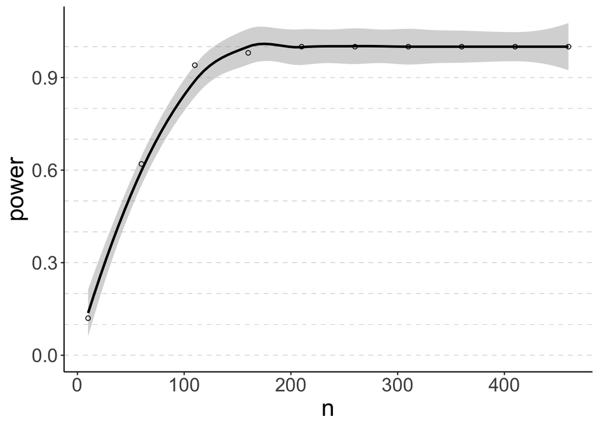

```r
set.seed(1)

# fit the model
fit = lm(formula = z ~ x * y,
               data = df.linear)

# extract beta coefficients
b = fit %>%
  tidy() %>%
  pull(estimate)

# extract the residual standard deviation
sigma = fit %>%
  glance() %>%
  pull(sigma)

# number of simulations
n_simulations = 50

# run simulation
df.power3 = crossing(n = seq(10, 500, 50),
                     simulation = 1:n_simulations) %>%
  mutate(index = 1:n()) %>%
  group_by(index, n, simulation) %>%
  mutate(data = list(tibble(x = runif(n = n),
                            y = rep(c(0, 1), each = n/2),
                            z = b[1] + b[2] * x + b[3] * y + b[4] * x * y + rnorm(n = n, sd = sigma)))) %>%
  group_by(index, n, simulation) %>%
  mutate(fit = map(.x = data,
                   .f = ~ lm(formula = z ~ x * y,
                              data = .x))) %>%
  mutate(coef = map(fit, tidy)) %>%
  select(simulation, n, index, coef) %>%
  unnest(cols = coef) %>%
  filter(term == "x:y") %>%
  group_by(n) %>%
  summarize(power = sum(p.value < 0.05) / n())

# visualize results
ggplot(data = df.power3,
       mapping = aes(x = n,
                     y = power)) +
  geom_hline(yintercept = seq(0, 1, 0.1),
             linetype = 2,
             color = "gray50",
             size = 0.1) +
  geom_smooth(method = "loess",
              color = "black") +
  geom_point(shape = 21)
```

Run the same power analysis this time assuming the ground truth parameters from the population (rather than the parameters that we’ve estimated from the sample).

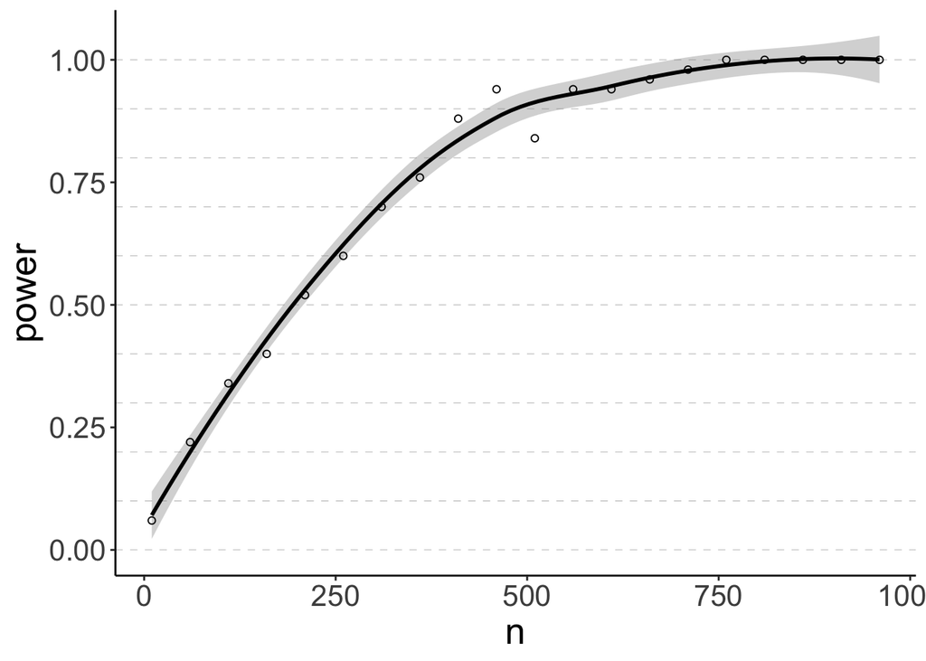

```r
set.seed(1)

# population parameters
b0 = 1
b1 = 2
b2 = 3
b1_2 = -2
sd = 2
n_simulations = 50

# run simulation
df.power4 = crossing(n = seq(10, 1000, 50),
                     simulation = 1:n_simulations) %>%
  mutate(index = 1:n()) %>%
  group_by(index, n, simulation) %>%
  mutate(data = list(tibble(x = runif(n = n),
                            y = rep(c(0, 1), each = n/2),
                            z = b0 + b1 * x + b2 * y + b1_2 * x * y + rnorm(n = n, sd = sd)))) %>%
  group_by(index, n, simulation) %>%
  mutate(fit = map(data,
                   ~ lm(formula = z ~ x * y,
                              data = .x))) %>%
  mutate(coef = map(fit, tidy)) %>%
  select(simulation, n, index, coef) %>%
  unnest(cols = coef) %>%
  filter(term == "x:y") %>%
  group_by(n) %>%
  summarize(power = sum(p.value < 0.05) / n())

# visualize results
ggplot(data = df.power4,
       mapping = aes(x = n,
                     y = power)) +
  geom_hline(yintercept = seq(0, 1, 0.1),
             linetype = 2,
             color = "gray50",
             size = 0.1) +
  geom_smooth(method = "loess",
              color = "black") +
  geom_point(shape = 21)
```